# Assignment 5

Harshita Singh

2024-05-26

# Information about the Data

- Who collected the data?  
  The data was collected by Vera institute of Justice using multiple sources but the most widely used source was the Nationals Corrections reporting program
- How was the data collected or generated? The most widely used source was the Nationals Corrections reporting program. To fill any gaps and errors in this data, additional data was collected from state department of correction reports .The collected data also underwent cleaning through manual inspection.
- Why was the data collected?  
  The data was collected to understand and analyze how counties across the United States contribute to state prison populations, with an aim to drive criminal justice policy and reform.
- How many observations (rows) are in the data?

there are 153811 rows in the data

- How many features (columns) are in the data?

there are 36 columns in the data

- What, if any, ethical questions or questions of power do you need to consider when working with this data?

The dataset includes sensitive information about individuals, such as race, gender, and county of commitment. There are ethical considerations regarding privacy and the potential for misuse of the data.

- What are possible limitations or problems with this data? (at least 200 words)

Some of the potential problems with this data are as follows: 1. Not all states particapted in the NCRP every year, which caused gaps in data and there was also some states that didn’t particapate at all creating even more gaps. 2.Estimating prison populations before the year 2000 was hard because NCRP records for this period wasn’t as well formatted and made estimation more complicated. 3.Different states have varying thresholds and practices for determining who goes to prison versus who serves a sentence in jail, which could affect the comparability of data across states.

# Introduction

The specific dataSet I chose out of the ones provided is the DataSet about prison population per county/state in the United States by the Vera Institute.

The specific variables that I have chosen to focus on are ( I am mentioning their names in the dataset itself):

1. “total_pop”
2. “total_prison_pop”
3. “black_prison_pop”

# Time Trend Chart

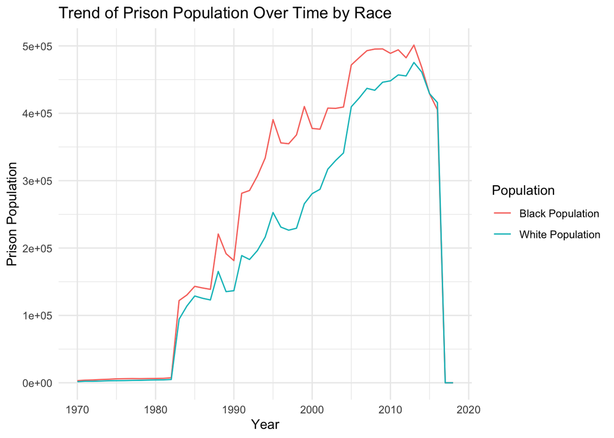

I included this chart to show the comparison of blace versus white prison population from 1970’s up until 2020 and i. noticed that starting from 1985, there was aa gap where black populations were higher but this gap has started to grow smaller around 2010’s.

# Variable Comparison Chart

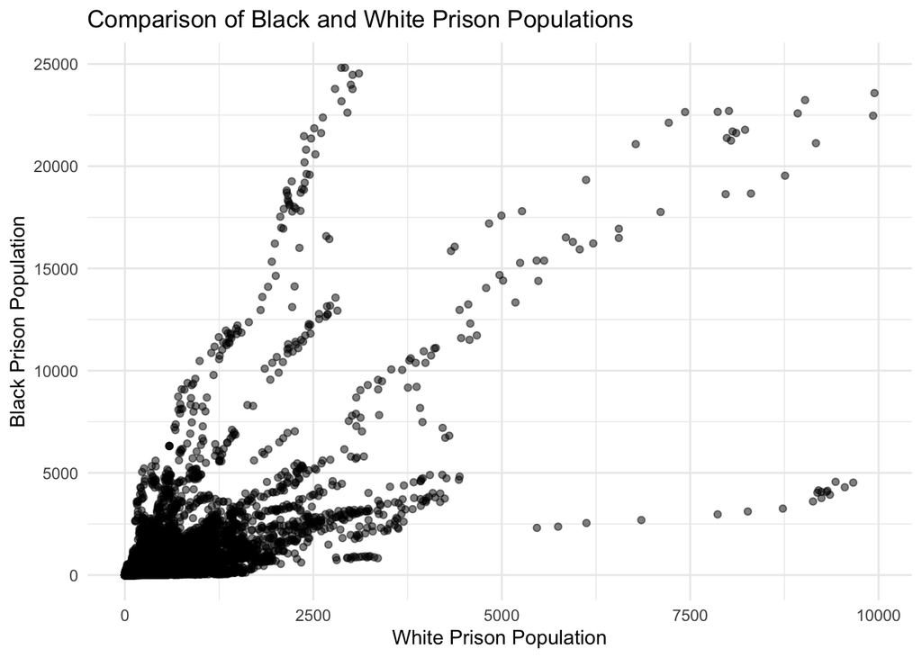

# Map

This map is included to show the geographic variation in the proportion of Black prisoners across different states. It helps identify regions with higher racial disparities in incarceration rates. The Southern states, in particular, show a higher proportion of Black prisoners

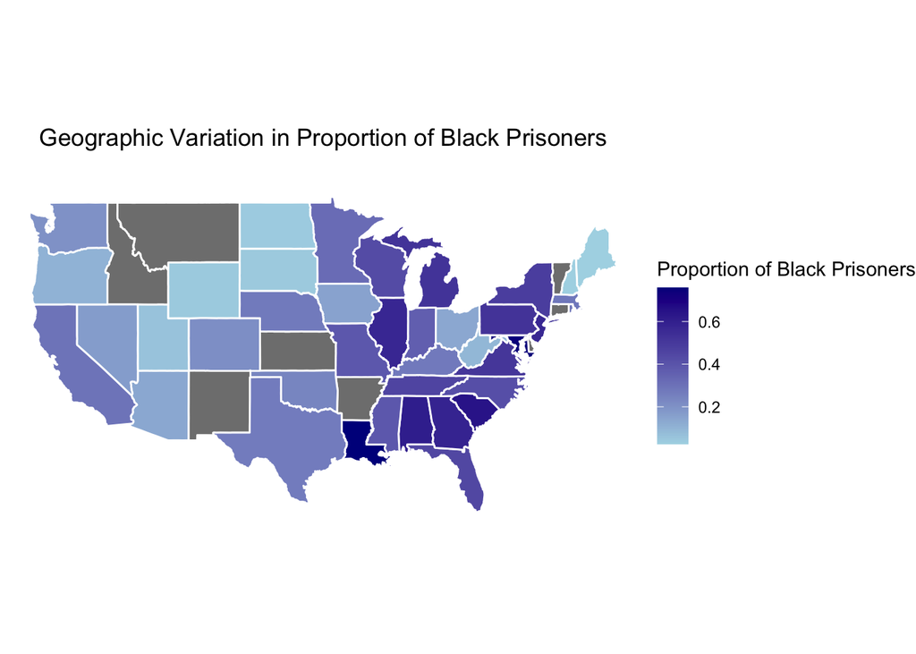